# The Bash Command Line

[figure not shown]

This tutorial makes you familiar with **bash**, the Linux command line. You will learn to:

- navigate directories
- manipulate files
- execute programs

If you have no previous experience with Unix-like systems or know a few commands but would like to know more, this tutorial is for you.

## Goal

In this tutorial, you will be looking for two words with 22 characters in total:

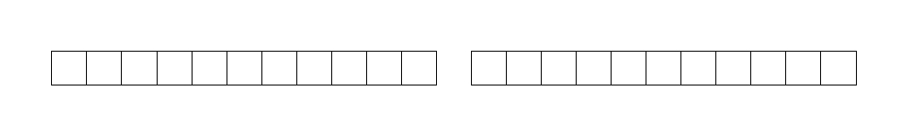

All characters are hidden in the exercises below.

To run the selected code cell, hit

`Shift + Enter`

## 1. Directories and files

```bash
cd
mkdir -p ~/kenya2026/IntroToBash
cp /course/popgenmsc26/exercises/linux/Exercises.zip ~/kenya2026/IntroToBash/
echo "Practice workspace created at: $(pwd)/kenya2026/IntroToBash"
```

```
Practice workspace created at: /home/jupyter-nuno/kenya2026/IntroToBash
```

You created your exercises folder `IntroToBash` and moved the Exercises file into it.

Now we need to decompress it so you can find the hidden characters

```bash
cd ~/kenya2026/IntroToBash
unzip Exercises.zip
```

```
Archive:  Exercises.zip
   creating: unix_tutorial/
   creating: unix_tutorial/exercises/
   creating: unix_tutorial/exercises/exercise_2/
  inflating: unix_tutorial/exercises/exercise_2/solution_2.1.txt
   creating: unix_tutorial/exercises/exercise_5/
 extracting: unix_tutorial/exercises/exercise_5/wrapped.zip
   creating: unix_tutorial/exercises/exercise_4/
  inflating: unix_tutorial/exercises/exercise_4/datascience.txt
  inflating: unix_tutorial/exercises/exercise_4/elephant.txt
  inflating: unix_tutorial/exercises/exercise_4/artificial_intelligence.txt
  inflating: unix_tutorial/exercises/exercise_4/ai.txt
   creating: unix_tutorial/exercises/exercise_3/
   creating: unix_tutorial/exercises/exercise_3/code2/
 extracting: unix_tutorial/exercises/exercise_3/code2/___+______+_.txt
   creating: unix_tutorial/exercises/exercise_3/code1/
 extracting: unix_tutorial/exercises/exercise_3/code1/UIMDELGKBCYF.txt
   creating: unix_tutorial/exercises/exercise_3/data/
 extracting: unix_tutorial/exercises/exercise_3/data/X_X_X_T_X_X_X
 extracting: unix_tutorial/exercises/exercise_3/data/X_X_X_X_X_E_X
 extracting: unix_tutorial/exercises/exercise_3/data/X_Y_X_X_X_X_H
 extracting: unix_tutorial/exercises/exercise_3/data/X_X_X_I_X_Y_X
 extracting: unix_tutorial/exercises/exercise_3/data/X_X_X_X_O_X_Y
 extracting: unix_tutorial/exercises/exercise_3/data/X_S_X_Y_X_X_X
 extracting: unix_tutorial/exercises/exercise_3/data/Y_X_X_X_X_W_X
 extracting: unix_tutorial/exercises/exercise_3/data/A_X_X_X_Y_X_X
  inflating: unix_tutorial/exercises/UnixReference.pdf
   creating: unix_tutorial/exercises/exercise_6/
  inflating: unix_tutorial/exercises/exercise_6/permissions.sh
   creating: unix_tutorial/exercises/exercise_1/
   creating: unix_tutorial/exercises/exercise_1/directoryC/
 extracting: unix_tutorial/exercises/exercise_1/directoryC/.hidden_file.txt
  inflating: unix_tutorial/exercises/exercise_1/directoryC/text_file.txt
   creating: unix_tutorial/exercises/exercise_1/directoryB/
 extracting: unix_tutorial/exercises/exercise_1/directoryB/program.sh
   creating: unix_tutorial/exercises/exercise_1/directoryB/solution_1.1/
 extracting: unix_tutorial/exercises/exercise_1/directoryB/solution_1.1/the_first_character_is_A
 extracting: unix_tutorial/exercises/exercise_1/directoryB/solution_1.1/.the_second_character_is_P
 extracting: unix_tutorial/exercises/exercise_1/directoryB/text_file.txt
   creating: unix_tutorial/exercises/exercise_1/directoryA/
   creating: unix_tutorial/exercises/exercise_1/directoryA/maybe_here/
 extracting: unix_tutorial/exercises/exercise_1/directoryA/maybe_here/sorry_not_here.txt
 extracting: unix_tutorial/exercises/exercise_1/directoryA/nothing_here.txt
  inflating: unix_tutorial/exercises/The One Page Linux Manual.pdf
```

### 1.1. Navigating directories

The **first character** is hidden in a file somewhere in the `exercise_1` directory tree. Use the commands

cd <directory_name>

```bash
cd unix_tutorial
ls
```

```
exercises
```

This is how you move from one directory to the next. Look through subdirectories until you find one with the name `solution_1.1` and list its contents. If you went to a wrong directory, you can go back one level by typing:

`cd ..`

```bash
cd exercises
ls
echo ""
cd exercise_1
ls
```

[output not shown]

Look within the directories in `exercise_1`

```bash
cd directoryA
ls
cd maybe_here
ls
```

```
maybe_here  nothing_here.txt
sorry_not_here.txt
```

It doesn't seem to have the answer. We need to go back and try another directory

`pwd` - will tell you where you are (our path)

```bash
cd ..
pwd
ls
cd ..
pwd
ls
```

```
/home/jupyter-nuno/kenya2026/IntroToBash/unix_tutorial/exercises/exercise_1/directoryA
maybe_here  nothing_here.txt
/home/jupyter-nuno/kenya2026/IntroToBash/unix_tutorial/exercises/exercise_1
directoryA  directoryB  directoryC
```

We are back to the first exercise directory. We will look into the second one `directoryB`

```bash
cd directoryB
ls
```

```
program.sh  solution_1.1  text_file.txt
```

We found `solution_1.1`!! We need to access it and we have our first letter

```bash
cd solution_1.1
ls
```

```
the_first_character_is_A
```

### 1.2. Show a hidden file

Some files are not visible immediately. To see them, you need the command

`ls -a`

The **second character**, is in the same directory as the first one `solution_1.1`, but in a hidden file.

```bash
ls -a
```

```
.  ..  the_first_character_is_A  .the_second_character_is_P
```

### 1.3. Execute a program

Use cd .. to go back to the directory `exercise_1/directoryB/`. When listing its contents, you should see a **shell script file** `program.sh`.

To find the **third character**, you need to execute the program. On bash, this is done by typing source and the name of the program:

```bash
cd ..
ls
source program.sh
```

```
program.sh  solution_1.1  text_file.txt
The third character is 'T'.
```

### 1.4. Find out how big a file is

Go to the folder `exercise_1/directoryC/`. To find **the fourth character**, you need to find out how big the text file in the directory is. This is done with the command

`ls -l`

```bash
cd ..
cd directoryC
ls -l
```

```
total 4
-rw-r--r-- 1 jupyter-nuno jupyter-nuno 69 Jan 30  2023 text_file.txt
```

In the table the command produces, you will find the file size in bytes, the file’s owner, permissions to read and modify it, and the date/time of the last modification.

To obtain the fourth character look up the file size in the [Table of printable ASCII characters](https://en.wikipedia.org/wiki/ASCII#Printable_characters) (use the decimal column):

[figure not shown]

*ASCII Table, Public Domain*

When typing names of directories or files, press `[TAB]` after the first few characters. Unix tries to guess what you are typing.

## 2. Edit text files

For the second section, we will change to the directory `exercise_2`.

```bash
cd ../..
cd exercise_2
ls
```

```
solution_2.1.txt
```

### 2.1. See what is in a text file

In the directory *exercise_2/*, you will find a text file *solution_2.1.txt*. The **fifth character** is inside that file. To see its contents, use the command

`less <filename>` or you can print the content into the terminal `cat solution_2.1.txt`

Type ‘q’ on your keyboard to exit the screen.

Because we are not in the terminal, I will copy the file content here:

```
`The fifth character of the solution is 'N'.

Did you know:
    The solution is usually well-dressed.`
```

### 2.2. Edit text files

To get **character number six**, you would need to create a text file in the `exercise_2` directory. On Ubuntu, you can do this using the editor `nano`. You can start it typing the name of the program, or

`nano <filename>`

**To exit nano, type Ctrl-X**

However, that is not possible in a notebook. So I will print here the options from nano and you have to pick the correct one:

```
^G Help        ^O Write Out   ^W Where Is    ^K Cut         ^T Execute     ^C Location    M-U Undo       M-A Set Mark
^X Exit        ^R Read File   ^\ Replace     ^U Paste       ^J Justify     ^/ Go To Line  M-E Redo       M-6 Copy
```

The **sixth character** is the one you need to press to save/write a file in `nano`.

## 3. Copy and remove files

Please go to the directory `exercise_3`.

```bash
cd ..
cd exercise_3
ls
```

```
code1  code2  data
```

### 3.1. Create a directory and copy a file to it.

To find **characters seven and eight**, you need to create a subdirectory named *solution* in `exercise_3/` and copy the files from the `code1/` and `code2/` folders into it.

For creating directories, use the command:

`mkdir <directory name>`

For copying, you can use the command

`cp <filename from> <filename to>`

Type `ls -l solution/*` afterwards to see the solution.

```bash
mkdir solution
ls
cp code1/* solution/
cp code2/* solution/
ls -l solution/*
```

```
code1  code2  data  solution
-rw-r--r-- 1 jupyter-nuno jupyter-nuno 0 Aug 19 15:13 solution/___+______+_.txt
-rw-r--r-- 1 jupyter-nuno jupyter-nuno 0 Aug 19 15:13 solution/UIMDELGKBCYF.txt
```

### 3.2. Removing files

In the `data` directory, all files with an `Y` need to be deleted. To do so, use the command:

`rm <filename>`

Also, there are more files to be deleted in the *data* directory. To remove more than one file at once, you can use `*` as a wildcard, i.e. `rm ju*` will delete all of `junk.txt, juniper.txt` and `june.docx`.

To get **characters nine and ten**, look at the files that remain after deleting all that contain a `Y`.

To remove an empty directory, you can use

`rmdir <directory name>`

The command

`rm -r <directory name>`

deletes a directory and everything in it.

**Be careful! On Unix, it is not possible to undelete files!**

This makes removing files with the `*` symbol **very** dangerous, because you could wipe out everything with a single command (e.g. if you type the wrong directory by accident). Backups become an even better idea after learning this command.

```bash
ls data
rm data/*Y*
echo ""
ls data
```

```
A_X_X_X_Y_X_X  X_X_X_I_X_Y_X  X_X_X_X_O_X_Y  X_Y_X_X_X_X_H
X_S_X_Y_X_X_X  X_X_X_T_X_X_X  X_X_X_X_X_E_X  Y_X_X_X_X_W_X

X_X_X_T_X_X_X  X_X_X_X_X_E_X
```

## 4. Process text data

Please go to the directory exercise_4.

```bash
cd ..
cd exercise_4
ls
```

```
ai.txt  artificial_intelligence.txt  datascience.txt  elephant.txt
```

### 4.1. comparing two files

There are two different versions of a quote, `ai.txt`, and `artificial_intelligence.txt`. To find out, how they differ, Unix provides the command

`diff <filename1> <filename2>`

The **11th character** of the solution is the single character in which the two files differ.

```bash
diff ai.txt artificial_intelligence.txt
```

```
6c6
< that they're too stupid
---
> that they're too tupid
```

### 4.2. Sorting a text file

Unix has a small program to sort text files alphabetically. It is called by

`sort <filename>`

The **12th character** of the solution is the first character of the last word in the alphabetically sorted file elephant.txt.

To store the sorted lines in a new file, you can add an output file, like

`sort <filename> > result.txt`

```bash
echo "<<this is how elephant.txt looks like>>"
head elephant.txt
echo ""
echo "<<this is after sort>>"
sort elephant.txt
```

```
<<this is how elephant.txt looks like>>
How beautiful...
This gigantic animal is a pachyderm.
Is an elephant's trunk!

<<this is after sort>>
How beautiful...
Is an elephant's trunk!
This gigantic animal is a pachyderm.
```

```bash
sort elephant.txt > result.txt
head result.txt
```

```
How beautiful...
Is an elephant's trunk!
This gigantic animal is a pachyderm.
```

### 4.3. Finding words in a text file

To look for specific words in a text file, use the command

`grep <word> <filename>`

It produces all lines from the given file that contain the given word. The `grep` command is very powerful and can handle Regular Expressions.

To find the **13th character**, search for the word **fire** in the file `datascience.txt` and take the **first** character of the output.

You can search through many files at once by including a * in the filename.

```bash
grep "fire" datascience.txt
```

```
a fire station
```

## 5. Unzip files

Please go to the directory exercise_5.

```bash
cd ..
cd exercise_5
ls
```

```
wrapped.zip
```

### 5.1. unzipping archives

Unzipping compressed files is a very basic and important task. On Unix, you often encounter WinZip archives, .tar archives and .gz compressed files. For unpacking Win zip files, use

`unzip <filename>`

for .tar and .tar.gz files

`tar -xf <filename>`

and for .gz files,

`gunzip <filename>`

The **14th and 15th character** of the solution are in a multiply wrapped archive in the exercise_5 directory.

To pack a directory and everything within, you can use the command

`tar -cf backup.tar <directory>`

To subsequently compress it, use

`gzip backup.tar`

```bash
unzip wrapped.zip
ls
echo "The file `wrapped.zip` has been unzipped. The contents are now available in the current directory."
tar -xf wrapped.tar
ls
```

```
Archive:  wrapped.zip
  inflating: wrapped.tar
wrapped.tar  wrapped.zip
wrapped.zip: command not found
The file  has been unzipped. The contents are now available in the current directory.
solution  wrapped.tar  wrapped.zip
```

You decompressed a directory!

```bash
cd solution
ls
echo "There is still one file to decompress"
echo ""
gunzip solution.txt.gz
echo "Finally!"
head solution.txt
```

```
solution.txt.gz
There is still one file to decompress

Finally!

Congratulations. You unwrapped everything.

The 14th character is: 'T'

The 15th character is: 'A'
```

## 6. Command-line tools

Please go to the directory `exercise_6`.

```bash
cd ../../exercise_6
ls -l
```

```
total 4
-rwxr-xr-x 1 jupyter-nuno jupyter-nuno 171 Jan 30  2023 permissions.sh
```

### 6.1. Changing file access rights

Each file on Unix has separate permissions for reading ‘r’, writing ‘w’, and executing ‘x’. Displaying them with:

`ls -l`

There is one triplet of permissions for the owner of the file owner, one triplet for a group of users, and one for all others. The `chmod` command allows to change these permissions, e.g.

`chmod a+x <filename>`

grants all users the permission to execute a file, while chmod u-w forbids the current user (oneself) to write to the file (thereby protecting it from being deleted accidentally).

To see **characters 16 and 17** of the solution, make the program `permissions.sh` executable. Then execute it with:

`./permissions.sh`

You can grant permissions for a whole directory tree using

`chmod -R a+x <directory>`

```bash
chmod a+x permissions.sh
ls -l
```

```
total 4
-rwxr-xr-x 1 jupyter-nuno jupyter-nuno 171 Jan 30  2023 permissions.sh
```

To run the script:

```bash
./permissions.sh
```

```
character 16 is:
G
character 17 is:
O
```

### 6.2. How much disk space have I left?

To find out, how much disk space you have left, you can use the command

`df`

`df` lists all hard drive partitions, CD-ROMs, pendrives and some logical partitions Unix uses. All numbers are given in kilobyte (1000 byte or one 1000000th GB).

To obtain the **18th character**, check out the version of the `df` program. Find out how to do that with:

`df --version`

The solution is the last character of the first authors’ first name.

```bash
df --version
```

```
df (GNU coreutils) 8.32
Copyright (C) 2020 Free Software Foundation, Inc.
License GPLv3+: GNU GPL version 3 or later <https://gnu.org/licenses/gpl.html>.
This is free software: you are free to change and redistribute it.
There is NO WARRANTY, to the extent permitted by law.

Written by Torbjorn Granlund, David MacKenzie, and Paul Eggert.
```

### 6.3. Set an environment variable

To install some programs, it is necessary to set so-called environment variables. These can be set using the command

`export <variable-name>=<value>`

You can see all variables by the command

`env`

To obtain the **19th character**, you need to use `export` to set the variable *GIVEME* to the value **SOLUTION** (i.e. assign the value ‘SOLUTION’ to the variable name ‘GIVEME’).

`echo $GIVEME`

Find out the **character’s position in the alphabet** with:

`echo $GIVEME | wc -c`

The symbol ‘|’ is called a pipe and is often used to connect Unix programs to each other.

By default, changes to environment variables only affect the current terminal.

If you want to set environment variables for each console window, write the export command to the file `.bashrc` in your home directory (it is a hidden file).

```bash
export GIVEME=SOLUTION
echo $GIVEME
echo $GIVEME | wc -c
```

```
SOLUTION
9
```

### 6.4. Check whether you have internet

The easiest way to check from the Unix command line whether the internet connection works, is to send a request to a known server (e.g. www.google.com) using the command

`ping <web address>`

The command reports, how long a message takes back and forth to the given server.

The **20th character** is the `ping` option that sets the maximum number of requests sent. In other words, look for the option that will stop sending packets after sending a user-defined number.

Check the documentation with:

`man ping`

```bash
man ping
```

```
PING(8)                             iputils                            PING(8)

NAME
       ping - send ICMP ECHO_REQUEST to network hosts

SYNOPSIS
       ping [-aAbBdDfhLnOqrRUvV46] [-c count] [-F flowlabel] [-i interval]
            [-I interface] [-l preload] [-m mark] [-M pmtudisc_option]
            [-N nodeinfo_option] [-w deadline] [-W timeout] [-p pattern]
            [-Q tos] [-s packetsize] [-S sndbuf] [-t ttl]
            [-T timestamp option] [hop...] {destination}

DESCRIPTION
       ping uses the ICMP protocol's mandatory ECHO_REQUEST datagram to elicit
       an ICMP ECHO_RESPONSE from a host or gateway. ECHO_REQUEST datagrams
       (“pings”) have an IP and ICMP header, followed by a struct timeval and
       then an arbitrary number of “pad” bytes used to fill out the packet.

       ping works with both IPv4 and IPv6. Using only one of them explicitly
       can be enforced by specifying -4 or -6.

       ping can also send IPv6 Node Information Queries (RFC4620).
       Intermediate hops may not be allowed, because IPv6 source routing was
       deprecated (RFC5095).

OPTIONS
       -4
           Use IPv4 only.

       -6
           Use IPv6 only.

       -a
           Audible ping.

       -A
           Adaptive ping. Interpacket interval adapts to round-trip time, so
           that effectively not more than one (or more, if preload is set)
           unanswered probe is present in the network. Minimal interval is
           200msec unless super-user. On networks with low RTT this mode is
```

[output cut: 340 more lines]

```

       As of version s20150815, the ping6 binary doesn't exist anymore. It has
       been merged into ping. Creating a symlink named ping6 pointing to ping
       will result in the same functionality as before.

SECURITY
       ping requires CAP_NET_RAW capability to be executed 1) if the program
       is used for non-echo queries (See -N option), or 2) if kernel does not
       support non-raw ICMP sockets, or 3) if the user is not allowed to
       create an ICMP echo socket. The program may be used as set-uid root.

AVAILABILITY
       ping is part of iputils package.

iputils 20211215                                                       PING(8)
```

### 6.5. Managing processes

To see what programs are running on your machine, type

`top`

It displays you a list of all currently active programs. *Shift+P* sorts them by the CPU time they are using, *Shift+M* by the amount of memory they are using (if you don’t see any program consuming lots of memory, start a web browser). Quit `top` by pressing *q*.

The **last two characters** of the solution are the first two characters of the second word in the line containing the column labels.

This is the head of the top command:

```
top - 15:33:28 up 105 days, 43 min,  5 users,  load average: 0.58, 0.50, 0.29
Tasks: 1016 total,   3 running, 1011 sleeping,   1 stopped,   1 zombie
%Cpu(s):  0.1 us,  0.1 sy,  0.0 ni, 99.8 id,  0.0 wa,  0.0 hi,  0.0 si,  0.0 st
MiB Mem : 386830.9 total,  46438.3 free,   7061.2 used, 333331.4 buff/cache
MiB Swap:   2048.0 total,   2043.2 free,      4.8 used. 376168.7 avail Mem

PID USER      PR  NI    VIRT    RES    SHR S  %CPU  %MEM     TIME+ COMMAND
3825499 jupyter+  20   0  238124 121944  18816 R   4.6   0.0   0:18.72 jupyterhub-sing
3824615 jupyter+  20   0  682252 130548  19896 S   4.3   0.0   0:55.35 jupyterhub-sing
3819792 jupyter+  20   0  610484 131624  19724 S   3.6   0.0   4:00.10 jupyterhub-sing
3825742 jupyter+  20   0   14344   5300   3500 R   1.3   0.0   0:01.05 top
3702764 systemd+  20   0   14836   6968   6116 S   0.7   0.0   5:17.98 systemd-oomd
3819936 jupyter+  20   0 4291040 149984  50304 S   0.7   0.0   0:34.67 python
```

If you want to get rid of one of the programs you started (e.g. because it crashed), you can do so by typing

`kill -s 9 <pid>`

You find the pid number in the first column of the *top* output. Of course, you may only interrupt your own programs, not those owned by *root*, the system administrator.

**Congratulations! You’ve completed the tutorial :)**

### License

**© 2010 Dr. Kristian Rother**

This tutorial is published under the Creative Commons Attribution Share-alike License 4.0

You can find the full sources on [<https://github.com/krother/bash\_tutorial\>](https://github.com/krother/bash_tutorial).

### Acknowledgements

I thank Janusz M. Bujnicki, Allegra Via, Pedro Fernandes and Joachim Jacob for their help with testing and reviewing the material. Further thanks go to the German Academic Exchange Service (DAAD) for financial support.

### Contact

Dr. Kristian Rother

krother@academis.eu

www.academis.eu